# Dealing with Unlabeled Data

## K-Means Clustering with Python

by [**Nosheen Altaf**](https://www.linkedin.com/in/nosheen-altaf-565158a/)

## Clustering Introduction

Cluster Analysis is an Unsupervised Machine Learning Technique with no prior information given about the group or cluster members.Cluster is the collection of data objects which are similar to one another within the same group and are different between clusters. Cluster analysis involves formulating a problem, selecting a distance measure, selecting a clustering procedure, deciding the number of clusters, interpreting the profile clusters and finally, assessing the validity of clustering.

There are three primary methods used to perform cluster analysis:

1: **Hierarchical Cluster**

Hierarchical procedure in cluster analysis is characterized by the development of a tree like structure. A hierarchical procedure can be agglomerative or divisive. Agglomerative methods in cluster analysis consist of linkage methods, variance methods, and centroid methods. Linkage methods in cluster analysis are comprised of single linkage, complete linkage, and average linkage

2: **K Means Cluster**

The non-hierarchical methods in cluster analysis are frequently referred to as K means clustering.

3: **Two-Steps Cluster**

Two-step cluster analysis is a combination of hierarchical and k-means cluster analysis

## Project Overview

This project uses the fish data set as input to demonstrate how to perform cluster analysis. Even though we have label for this dataset but we will only be utilizing this information to validate our findings. We will visualize the clusters by using Linear discriminant analysis (LDA)

## The Data:

[Fish Data](http://support.sas.com/documentation/cdl/en/stsug/62259/HTML/default/viewer.htm#ugappdatasets_sect8.htm) contains measurements of 159 fish caught in Finland's Lake Laengelmavesi.The following list describes each variable.

1. **species**: species of fish
2. **weight** : weight of the fish, in grams
3. **length1**: length of the fish from the nose to the beginning of the tail, in centimeters
4. **length2**: length of the fish from the nose to the notch of the tail, in centimeters
5. **length3**:length of the fish from the nose to the end of the tail, in centimeters
6. **height**: maximum height of the fish, in centimeters
7. **width**: maximum width of the fish, in centimeters

## Get the Data

```python
import pandas as pd
import numpy as np
import matplotlib.pyplot as plt
import seaborn as sns
import warnings
warnings.filterwarnings('ignore')
%matplotlib inline
```

```python
df=pd.read_csv('fish.csv')
```

## Data Investigation

Lets get familiar with our data by viewing it!

we will examine the data for null values, inconsistency in levels of categorical variables, variable info ,variable type etc.

```python
df.head() #first 5 rows
```

|  | Species | Weight | Length1 | Length2 | Length3 | Height | Width |
| --- | --- | --- | --- | --- | --- | --- | --- |
| 0 | Bream | 242.0 | 23.2 | 25.4 | 30.0 | 11.5200 | 4.0200 |
| 1 | Bream | 290.0 | 24.0 | 26.3 | 31.2 | 12.4800 | 4.3056 |
| 2 | Bream | 340.0 | 23.9 | 26.5 | 31.1 | 12.3778 | 4.6961 |
| 3 | Bream | 363.0 | 26.3 | 29.0 | 33.5 | 12.7300 | 4.4555 |
| 4 | Bream | 430.0 | 26.5 | 29.0 | 34.0 | 12.4440 | 5.1340 |

```python
df.tail() #last 5 rows
```

|  | Species | Weight | Length1 | Length2 | Length3 | Height | Width |
| --- | --- | --- | --- | --- | --- | --- | --- |
| 154 | Smelt | 12.2 | 11.5 | 12.2 | 13.4 | 2.0904 | 1.3936 |
| 155 | Smelt | 13.4 | 11.7 | 12.4 | 13.5 | 2.4300 | 1.2690 |
| 156 | Smelt | 12.2 | 12.1 | 13.0 | 13.8 | 2.2770 | 1.2558 |
| 157 | Smelt | 19.7 | 13.2 | 14.3 | 15.2 | 2.8728 | 2.0672 |
| 158 | Smelt | 19.9 | 13.8 | 15.0 | 16.2 | 2.9322 | 1.8792 |

```python
len(df) #total number of observations
```

```
159
```

```python
df.isnull().sum()#to check null values
```

```
Species    0
Weight     1
Length1    0
Length2    0
Length3    0
Height     0
Width      0
dtype: int64
```

we have one missing value in weight column. we will address this in **Data Preparation** section

```python
df.info()
```

```
<class 'pandas.core.frame.DataFrame'>
RangeIndex: 159 entries, 0 to 158
Data columns (total 7 columns):
Species    159 non-null object
Weight     158 non-null float64
Length1    159 non-null float64
Length2    159 non-null float64
Length3    159 non-null float64
Height     159 non-null float64
Width      159 non-null float64
dtypes: float64(6), object(1)
memory usage: 8.8+ KB
```

There is only one categorical variable i-e Species, we can get the list of unique values to see if there is any inconsistency at different level of the categorical variable.

```python
df['Species'].unique()
```

```
array(['Bream', 'Roach', 'Whitefish', 'Parkki', 'Perch', 'Pike', 'Smelt'],
      dtype=object)
```

```python
df.describe().round(2) # to see summary statistics
```

|  | Weight | Length1 | Length2 | Length3 | Height | Width |
| --- | --- | --- | --- | --- | --- | --- |
| count | 158.00 | 159.00 | 159.00 | 159.00 | 159.00 | 159.00 |
| mean | 398.70 | 26.25 | 28.42 | 31.23 | 8.97 | 4.42 |
| std | 359.09 | 10.00 | 10.72 | 11.61 | 4.29 | 1.69 |
| min | 0.00 | 7.50 | 8.40 | 8.80 | 1.73 | 1.05 |
| 25% | 120.00 | 19.05 | 21.00 | 23.15 | 5.94 | 3.39 |
| 50% | 272.50 | 25.20 | 27.30 | 29.40 | 7.79 | 4.25 |
| 75% | 650.00 | 32.70 | 35.50 | 39.65 | 12.37 | 5.58 |
| max | 1650.00 | 59.00 | 63.40 | 68.00 | 18.96 | 8.14 |

## Data Preparation

### Dealing with Missing Value

Since our data has only one missing observation, we can simply drop it and it wont effect the result. However, just to show how to handle missing data, we will impute that one missing value.

Lets first examine the row with missing value

```python
df[df.isnull()['Weight']==True]
```

|  | Species | Weight | Length1 | Length2 | Length3 | Height | Width |
| --- | --- | --- | --- | --- | --- | --- | --- |
| 13 | Bream | NaN | 29.5 | 32.0 | 37.3 | 13.9129 | 5.0728 |

To impute missing value for this specie, let examine summary statistics group by species

```python
df[['Species','Weight']].groupby(['Species']).describe().round(2)
```

| Species | Weight count | Weight mean | Weight std | Weight min | Weight 25% | Weight 50% | Weight 75% | Weight max |
| --- | --- | --- | --- | --- | --- | --- | --- | --- |
| Bream | 34.0 | 626.00 | 206.60 | 242.0 | 481.25 | 615.00 | 718.50 | 1000.0 |
| Parkki | 11.0 | 154.82 | 78.76 | 55.0 | 105.00 | 145.00 | 185.00 | 300.0 |
| Perch | 56.0 | 382.24 | 347.62 | 5.9 | 120.00 | 207.50 | 692.50 | 1100.0 |
| Pike | 17.0 | 718.71 | 494.14 | 200.0 | 345.00 | 510.00 | 950.00 | 1650.0 |
| Roach | 20.0 | 152.05 | 88.83 | 0.0 | 104.25 | 147.50 | 171.75 | 390.0 |
| Smelt | 14.0 | 11.18 | 4.13 | 6.7 | 8.95 | 9.85 | 12.20 | 19.9 |
| Whitefish | 6.0 | 531.00 | 309.60 | 270.0 | 279.00 | 423.00 | 735.00 | 1000.0 |

We can see that average weight is different for each species. We can replace missing values with species group mean value if the data is not skewed.

Lets examine the distribution of the Species 'Bream'

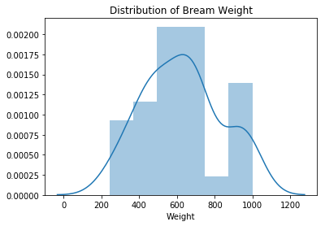

```python
sns.distplot(df.query("Species=='Bream'")['Weight'].dropna()).set_title('Distribution of Bream Weight');
```

Since data has central tendency towards average, so we can replace missing value by its mean value

```python
df.fillna(value=df.query("Species=='Bream'")['Weight'].mean(),inplace=True)
```

Lets see if missing value is imputed successfully

```python
df.iloc[13:14,:]
```

|  | Species | Weight | Length1 | Length2 | Length3 | Height | Width |
| --- | --- | --- | --- | --- | --- | --- | --- |
| 13 | Bream | 626.0 | 29.5 | 32.0 | 37.3 | 13.9129 | 5.0728 |

Now our data has no missing value, we can re confirm this by running following line of code

```python
df.isnull().sum()
```

```
Species    0
Weight     0
Length1    0
Length2    0
Length3    0
Height     0
Width      0
dtype: int64
```

## Data Visualization

Lets perform some exploratory data analysis by visualizing the relationship of different features of fish dataset.

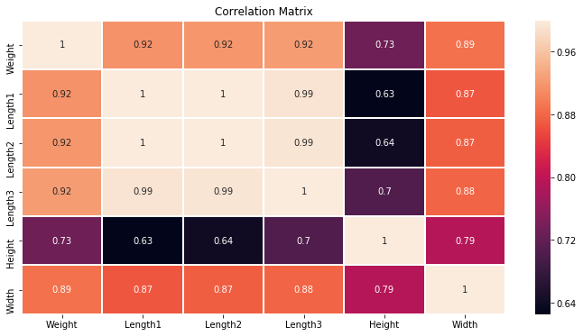

```python
plt.figure(figsize=(12, 6))
sns.heatmap(df.corr(),annot=True,linewidths=1).set_title('Correlation Matrix');
```

We can see that Length2 and Length 3 are significantly and highly correlated with the variable Length1. We can further examine the linear relationship by creating scatter plots

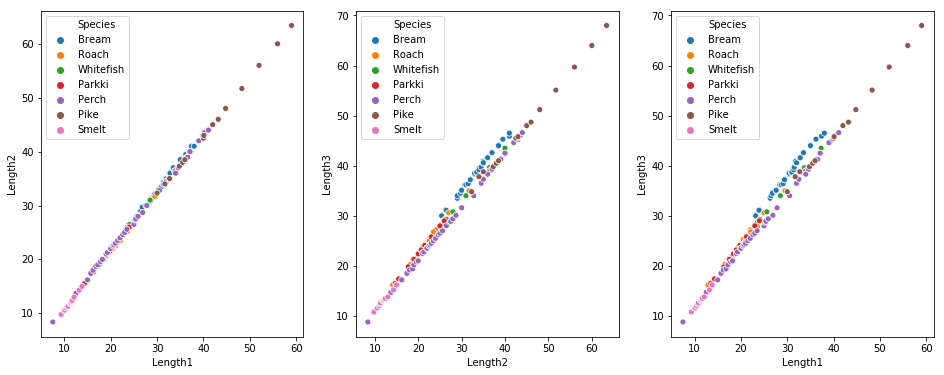

```python
plt.figure(figsize=(16, 6))
plt.subplot(1,3,1)
sns.scatterplot(data=df,x='Length1',y='Length2',hue='Species');
plt.subplot(1,3,2)
sns.scatterplot(data=df,x='Length2',y='Length3',hue='Species');
plt.subplot(1,3,3)
sns.scatterplot(data=df,x='Length1',y='Length3',hue='Species');
```

Note that the variables Length2 and Length3 can be eliminated from this analysis since they both are significantly and highly correlated with the variable Length1.

```python
df=df.drop(['Length2','Length3'],axis=1) #dropping the Length2 and Length3
```

```python
df.head()
```

|  | Species | Weight | Length1 | Height | Width |
| --- | --- | --- | --- | --- | --- |
| 0 | Bream | 242.0 | 23.2 | 11.5200 | 4.0200 |
| 1 | Bream | 290.0 | 24.0 | 12.4800 | 4.3056 |
| 2 | Bream | 340.0 | 23.9 | 12.3778 | 4.6961 |
| 3 | Bream | 363.0 | 26.3 | 12.7300 | 4.4555 |
| 4 | Bream | 430.0 | 26.5 | 12.4440 | 5.1340 |

Lets examine the pairwise relationships in the dataset.

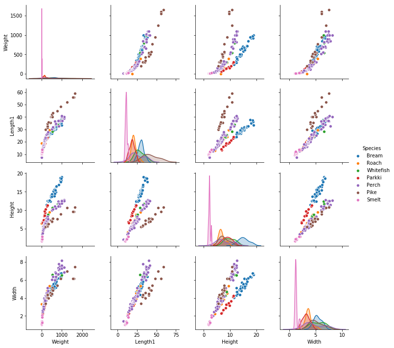

```python
plt.figure(figsize=(14, 12))
sns.pairplot(data=df,hue='Species');
```

We can see the distribution analysis of different features for different species and overlapping of features

## Feature Scaling

Differences in the scales across features may increase the difficulty of the problem being modeled. we can standardize our data by using SK Learn Standard Scaler

```python
df1=df.iloc[:,1:] #creating a feature Data set
```

```python
df1.head()
```

|  | Weight | Length1 | Height | Width |
| --- | --- | --- | --- | --- |
| 0 | 242.0 | 23.2 | 11.5200 | 4.0200 |
| 1 | 290.0 | 24.0 | 12.4800 | 4.3056 |
| 2 | 340.0 | 23.9 | 12.3778 | 4.6961 |
| 3 | 363.0 | 26.3 | 12.7300 | 4.4555 |
| 4 | 430.0 | 26.5 | 12.4440 | 5.1340 |

```python
from sklearn.preprocessing import StandardScaler
```

```python
scaler=StandardScaler()
```

```python
scaler.fit(df1)
```

```
StandardScaler(copy=True, with_mean=True, with_std=True)
```

```python
df2=scaler.transform(df1) # df2 is our scaled data
```

### Choosing a K Value

There is no easy answer of choosing a 'best' K value! we can plot within cluster SSE(sum of squared error) at different value of K and choose K at which the SSE decreases abruptly. This produces an elbow effect in graph and called elbow method.

```python
from sklearn.cluster import KMeans
```

```python
sse=[]
for i in range(1, 10):
    kmeans = KMeans(n_clusters=i, max_iter=1000).fit(df2)
    sse_i = kmeans.inertia_ # Inertia: Sum of distances of samples to their closest cluster center
    sse.append(sse_i)
```

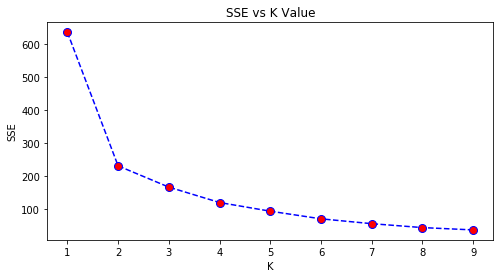

```python
plt.figure(figsize=(8,4))
plt.plot(range(1,10),sse,color='blue',linestyle='dashed',marker='o',markersize=8,
         markerfacecolor='red')
plt.title('SSE vs K Value')
plt.xlabel('K')
plt.ylabel('SSE')
plt.show()
```

### Clusters Computing

```python
kmeans=KMeans(n_clusters=7,max_iter=1000)
```

```python
kmeans.fit(df2)
```

```
KMeans(algorithm='auto', copy_x=True, init='k-means++', max_iter=1000,
    n_clusters=7, n_init=10, n_jobs=1, precompute_distances='auto',
    random_state=None, tol=0.0001, verbose=0)
```

### Cluster Centroid Table

We can interpret the profiling variables of each segment/Cluster by using Cluster Centroid Table

```python
pd.DataFrame(data=kmeans.cluster_centers_,columns=['Weight','Length','Height','Width'],
             index=['Cluster1','Cluster2','Cluster3','Cluster4','Cluster5','Cluster6','Cluster7'])
```

|  | Weight | Length | Height | Width |
| --- | --- | --- | --- | --- |
| Cluster1 | 0.156902 | 1.204960 | -0.483818 | 0.085281 |
| Cluster2 | 1.248504 | 1.048047 | 0.588114 | 1.504909 |
| Cluster3 | -1.077274 | -1.494956 | -1.520445 | -1.740435 |
| Cluster4 | -0.763018 | -0.666661 | -0.603240 | -0.600689 |
| Cluster5 | 0.796394 | 0.512251 | 1.590139 | 0.709114 |
| Cluster6 | 3.113516 | 2.960658 | 0.281691 | 1.351233 |
| Cluster7 | -0.268236 | -0.087524 | 0.136498 | 0.081150 |

## Evaluation

There is no perfect way to evaluate clustering if we don't have the labels, since we do have the labels, so we can actually analyze if groups make sense

```python
clus=kmeans.labels_ #Assigned clusters
```

```python
lab=df['Species'] #Actual labels
```

```python
#Creating a cross-tabulation of Actual vs Assigned Label

ct=pd.crosstab(lab,clus)
ct.columns.name=''
ct.rename(columns={0:'Cluster1',1:'Cluster2',2:'Cluster3',3:'Cluster4',4:'Cluster5',5:'Cluster6',6:'Cluster7'})
```

| Species | Cluster1 | Cluster2 | Cluster3 | Cluster4 | Cluster5 | Cluster6 | Cluster7 |
| --- | --- | --- | --- | --- | --- | --- | --- |
| Bream | 0 | 0 | 0 | 0 | 29 | 0 | 6 |
| Parkki | 0 | 0 | 0 | 8 | 0 | 0 | 3 |
| Perch | 0 | 18 | 3 | 26 | 0 | 0 | 9 |
| Pike | 11 | 1 | 0 | 1 | 0 | 4 | 0 |
| Roach | 0 | 0 | 1 | 16 | 0 | 0 | 3 |
| Smelt | 0 | 0 | 14 | 0 | 0 | 0 | 0 |
| Whitefish | 0 | 3 | 0 | 0 | 0 | 0 | 3 |

## Visualization of Actual vs Assigned Clusters using Linear Discriminent Analysis (LDA)

Now we have labels for our data, however our data is multidimensional and we need fewer dimensions to view and understand the data.

To reduce dimensions, we can use Linear Discriminant Analysis. Linear Discriminant Analysis(LDA) is a very common technique used for supervised classification problems

The goal of [Linear Discriminant Analysis](https://en.wikipedia.org/wiki/Linear_discriminant_analysis) is to project the features in higher dimension space onto a lower dimensional space

```python
from sklearn.discriminant_analysis import LinearDiscriminantAnalysis
```

```python
LDA = LinearDiscriminantAnalysis(n_components=2)
```

```python
data_proj = LDA.fit_transform(df2,lab)
```

```python
#creating a dataframe with two components along with actual and assigned label

data=pd.DataFrame(data=data_proj,columns=['Can1','Can2'])
data['Label']=lab
data['Cluster']=clus
dict={0:'Clus1',1:'Clus2' ,2:'Clus3',3:'Clus4',4:'Clus5',5:'Clus6',6:'Clus7'}
data=data.replace({'Cluster':dict})
```

```python
data.head()
```

|  | Can1 | Can2 | Label | Cluster |
| --- | --- | --- | --- | --- |
| 0 | -5.469521 | -1.132857 | Bream | Clus7 |
| 1 | -6.452534 | -1.131331 | Bream | Clus7 |
| 2 | -5.878701 | 0.058504 | Bream | Clus7 |
| 3 | -5.989562 | -1.791406 | Bream | Clus7 |
| 4 | -4.673022 | 0.013125 | Bream | Clus7 |

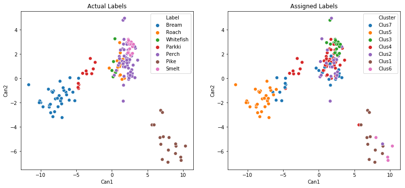

```python
#Plotting Actual vs Assigned Labels

plt.figure(figsize=(14, 6))
plt.subplot(1,2,1)
sns.scatterplot(x='Can1', y='Can2', hue='Label',s= 50,
                data=data).set_title("Actual Labels")
plt.subplot(1,2,2)
sns.scatterplot(x='Can1', y='Can2', hue='Cluster',s=50,
                data=data).set_title("Assigned Labels");
```

We can view side by side actual and assigned label.

## Conclusion:

Cluster Analysis divides the data into meaningful groups. The overall goal is to divide data into distinct groups with similar observations within groups. There have been many applications of cluster analysis to practical problems such as pattern recognition, marketing research, image processing and data analysis etc.

## References:

```
1.http://support.sas.com/documentation/cdl/en/stsug/62259/HTML/default/viewer.htm#ugappdatasets_sect8.htm
2.https://www.statisticssolutions.com/directory-of-statistical-analyses-cluster-analysis/
3.https://www.udemy.com/course/python-for-data-science-and-machine-learning-bootcamp/
```